# Write up Assignment

Dorri

Saturday, April 25, 2015

I started by loading the data. From examining the data I saw that there are cells with *NA*, empty cells, and cells with *#DIV/0!*, which should all be considered as *NA*:

```r
full_training_data<-read.csv("pml-training.csv",na.strings=c("NA","NaN","","#DIV/0!"))
```

First, I divided the training database into a training set and a cross validation set:

```r
require("caret")
require("kernlab")
require("doParallel")
set.seed(1263)
inTrain<-createDataPartition(y=full_training_data$"classe",p=0.75,list=FALSE)

training<-full_training_data[inTrain,]
nam<-names(training)
y<-training$"classe"

CV<-full_training_data[-inTrain,]
yCV<-CV$"classe"
```

I specified the numeric data column, and stored them into a separate data.frame:

```r
sen_range<-c(8:158)
sensor_data<-training[,sen_range]
CV_sensor_data<-CV[,sen_range]

sens_nam<-nam[sen_range]
```

Next, I examined the sparsity of the data, and took a few diagnostics indicating the density of *NA* values, so that I could make a decision regarding the data imputation strategy:

```r
rcomplete<-complete.cases(sensor_data)
sensor_data.comp<-sensor_data[rcomplete,]

countna_func<-function(x) { return(length(which(is.na(x))))}
count_na<-lapply(sensor_data,countna_func)

r_na<-which(count_na>0.9*nrow(sensor_data))
sensor_data.comp<-sensor_data[complete.cases(sensor_data),]

r<-range(as.numeric(count_na[r_na]))
```

There are 100, sensor columns which contain mostly empty cells, of which the number of empty cells ranges between 14411 and 14718. In these the std of missing data number is 74. The total number of *NA* outside this group is 0. There are exactly 0 complete cases, and the total number of observations is 14718. At the Bottom line, we can omit each sensor which has *NA*, without losing meaninful variance of the data in this case.

```r
sensor_data.imputed<-sensor_data[-r_na]
nam.imputed<-names(sensor_data.imputed)

CV_sensor_data.imputed<-CV_sensor_data[-r_na]

m<-length(nam.imputed)
n<-nrow(sensor_data.imputed)
```

We are left with 14718 observations and 51 sensors which we are going to use for the training sessions. Next I wanted to get a better understanding of the distribution of variance in the data, so I looked the the principle component analysis of the data:

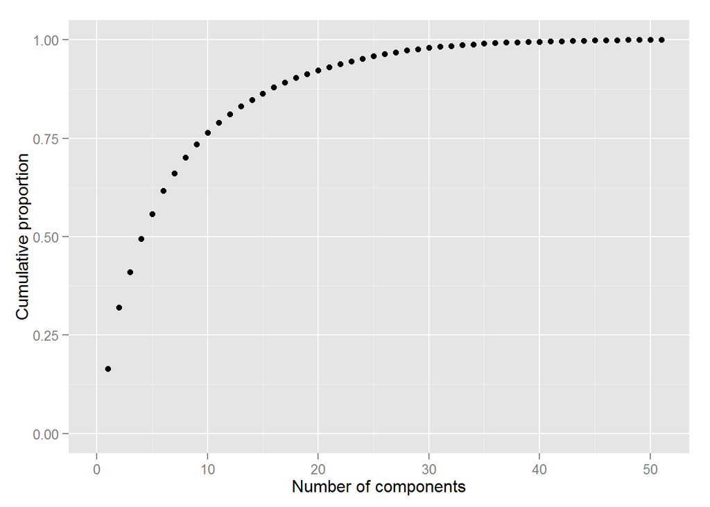

```r
sensor_data.pca<-prcomp(sensor_data.imputed,center=TRUE,scale.=TRUE)
tot<-sum(sensor_data.pca$"sdev"^2)
Cumulative_proportion<-numeric(m); toti<-0
for(i in 1:m){ toti<-toti+sensor_data.pca$"sdev"[i]^2; Cumulative_proportion[i]<-toti/tot}
qplot(c(1:m),Cumulative_proportion,xlab="Number of components",ylab="Cumulative proportion",ylim=c(0,1),xlim=c(0,m))
```

One needs 24 components to get 95% of the variance, which is a large portion of the components of the problem. So we reach the conclusion that the variance is distributed and not local, and we will not attempt any further dimensionality reduction. Next I attempted a linear SVM classifier:

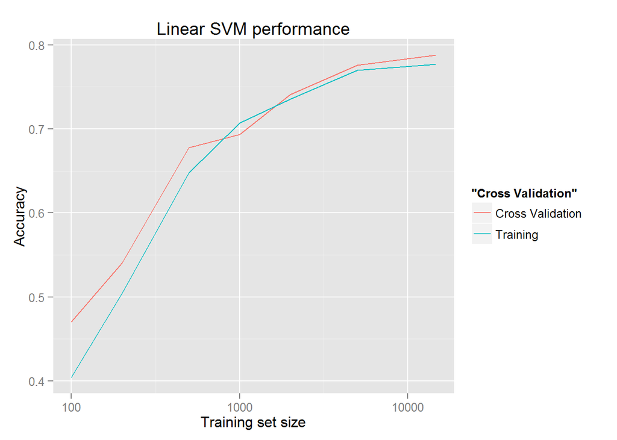

```r
  Ntrain_vect<-c(100,200,500,1000,2000,5000,n)

  trControl<-trainControl(method = 'cv', number = 5, allowParallel = TRUE)
  model_list1<-list()
  SVMTrainingAccuracy_vect<-numeric(length(Ntrain_vect))
  SVMCVAccuracy_vect<-numeric(length(Ntrain_vect))

    for(i in 1:length(Ntrain_vect)){
        rtrain<-sample(1:n, Ntrain_vect[i])
    xi<-sensor_data.imputed[rtrain,]
    yi<-y[rtrain]
        mod.SVM<-train(x=xi,y=yi, method="svmLinear",preProcess = c('center', 'scale'), trControl=trControl)
    model_list1[[length(model_list1)+1]]<-mod.SVM
    vCV<-predict(mod.SVM,CV_sensor_data.imputed)
    CM_CV<-confusionMatrix(vCV,yCV)
    SVMCVAccuracy_vect[i]<-CM_CV$"overall"[["Accuracy"]]
      SVMTrainingAccuracy_vect[i]<-mod.SVM$"results"[["Accuracy"]]
    }
  df<-data.frame(Ntrain_vect,SVMTrainingAccuracy_vect,SVMCVAccuracy_vect)
  ggplot(df, aes(x=df$Ntrain_vect))+scale_x_log10() +
            geom_line(aes(x=df$Ntrain_vect,y = SVMCVAccuracy_vect, col = 'Cross Validation'))+
            geom_line(aes(y = SVMTrainingAccuracy_vect, col = 'Training'))+
        xlab("Training set size")+ylab("Accuracy")+labs(title="Linear SVM performance")
```

```r
  CM_CV<-confusionMatrix(predict(model_list1[[length(model_list1)]],CV_sensor_data.imputed),yCV)
  CM_CV["table"]
```

```
## $table
##           Reference
## Prediction    A    B    C    D    E
##          A 1280  136   58   40   47
##          B   29  659   80   29  127
##          C   38   67  664   80   54
##          D   42   25   23  627   40
##          E    6   62   30   28  633
```

This way an accuracy of about 80% was reached on the cross validation group. At this point I suspected that perhaps I could improve the performance if I treat this problem as a regression problem other than a classification problem. Since if the classe for a given observation is, for example, “B” and the prediction is “A” it should be regarded as a better prediction than if it was “D”. So I performed another attempt with SVM, this time I treated the classe field as a number in 1:5, and attempted to minimize the RMSE. However, this attempt gave inferior results to the previous attempt, of the order 50% accuracy after training over almost 15000 cases. The accuracy we got so far is not satisfactory, so I searched for an alternative method, and decided to attempt a random forest algorithm, using the randomForest forest package.

```r
  require("randomForest")
```

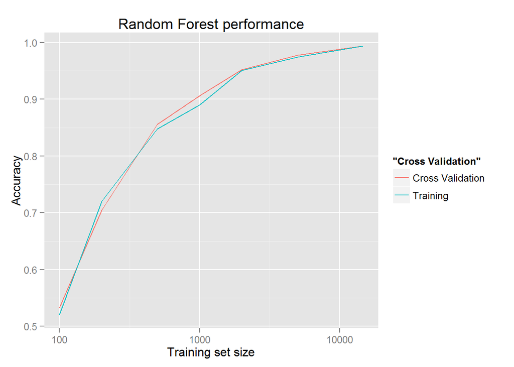

```r
  RFCVAccuracy_vect<-numeric(length(Ntrain_vect))
  RFTrainingAccuracy_vect<-numeric(length(Ntrain_vect))
  model_list3<-list()
  tpgrid<-expand.grid(mtry=c(7)) #approximately sqrt(m)
  trControl<-trainControl(method = 'cv', number = 5, allowParallel = TRUE)
    for(i in 1:length(Ntrain_vect)){
        rtrain<-sample(1:n, Ntrain_vect[i])
    xi<-sensor_data.imputed[rtrain,]
    yi<-y[rtrain]

    mod.RF<-train(x=xi,y=yi, method="rf", trControl=trControl,tuneGrid=tpgrid)
      model_list3[[length(model_list3)+1]]<-mod.RF
    vCV<-predict(mod.RF,CV_sensor_data.imputed)
    CM_CV<-confusionMatrix(vCV,yCV)
      RFTrainingAccuracy_vect[i]<-model_list3[[i]]$"results"[["Accuracy"]]
    RFCVAccuracy_vect[i]<-CM_CV$"overall"[["Accuracy"]]
    }
  df<-data.frame(Ntrain_vect,RFTrainingAccuracy_vect,RFCVAccuracy_vect)
  ggplot(df, aes(x=df$Ntrain_vect))+scale_x_log10() +
            geom_line(aes(x=df$Ntrain_vect,y = RFCVAccuracy_vect, col = 'Cross Validation'))+
            geom_line(aes(y = RFTrainingAccuracy_vect, col = 'Training'))+
        xlab("Training set size")+ylab("Accuracy")+labs(title="Random Forest performance")
```

```r
  CM_CV<-confusionMatrix(predict(model_list3[[length(model_list3)]],CV_sensor_data.imputed),yCV)
  CM_CV["table"]
```

```
## $table
##           Reference
## Prediction    A    B    C    D    E
##          A 1394    5    0    0    0
##          B    1  942    6    0    0
##          C    0    2  846   10    0
##          D    0    0    3  792    2
##          E    0    0    0    2  899
```

This approach proved to be very successful with an accuracy rate of about 99% over the ~5000 cross-validation cases after training over the ~15000 training cases. This success rate is way beyond what I expected to get from a predicitive model after examining the data, and searching for patterns, so I believe this would be considered a successful learning case.